# Code Sample 1: Cleaning & Tidying Data

David I. Crabtree

2/19/2023

# Overview

The FreedomHouse dataset is a common tool for researchers studying the strength of democracy around the world. However, the raw data provided on [FreedomHouse’s](https://freedomhouse.org/) website is obnoxiously messy, leaving researchers to do the work of cleaning and tidying the data before running analyses. Below I import FreedomHouse’s data from their website and show how it can be cleaned using reproducible code. After cleaning the data, I build a few graphs to show background in ggplot.

A more extensive version of my work with FreedomHouse data, including 200+ procedurally generated country profiles, is available on [my website](https://davidicrabtree.com/projects/democracy-reports/).

# Importing FreedomHouse Data

Note that the FreedomHouse data directly downloaded from the FH website is very messy: the columns have empty variables (“X3, X4. . .”) combined with years every third interval. The first row contains the names of the variables we are interested in. In the first row, “PR” represents an index of “Political Rights”, “CL” represents an index of “Civil Liberties”, and “Status” represents a categorical variable defining whether a country is “Free”, “Partly Free”, or “Not Free” according to FreedomHouse’s coders. These variables need to eventually become the columns.

```r
fh_url <- "https://freedomhouse.org/sites/default/files/2022-03/Country_and_Territory_Ratings_and_Statuses_FIW_1973-2022%20.xlsx"

fh <- read.xlsx(fh_url,
                sheet = 2,
                na.strings = "-",
                startRow = 2)


head(fh, c(5, 10))
```

```
##   Year(s).Under.Review 1972  X3     X4 1973  X6     X7 1974  X9    X10
## 1                 <NA>   PR CL  Status   PR CL  Status   PR CL  Status
## 2          Afghanistan    4   5     PF    7   6     NF    7   6     NF
## 3              Albania    7   7     NF    7   7     NF    7   7     NF
## 4              Algeria    6   6     NF    6   6     NF    6   6     NF
## 5              Andorra    4   3     PF    4   4     PF    4   4     PF
```

# Cleaning & Tidying FreedomHouse Data

Note the pattern. The variables repeat every third column as follows:  
PR, CL, Status, PR, CL, Status, PR, CL, Status  
Also note that the year is currently where PR should be, X3 is where CL should be, X4 where status should be, and so on. Year also advances every third column

We can replicate the sequence that the variables repeat in the data with `seq()`. Note that below is the sequence for the CL variable.

```r
head(seq(from = 2, to = 30135, by = 3))
```

```
## [1]  2  5  8 11 14 17
```

I start by renaming the first column to “country” and then pivoting so that all current columns except “country” become values for a new column called “Rate Type” and all current values in the selected columns become values for a new column called “Score”. I have noted the pattern that the important variables (PR, CL, and status) repeat with, so I remove the row with that data for now.

```r
# Rename first column to "country"
names(fh)[1] <- "country"

fh_clean <- fh %>%
  filter(!is.na(country)) %>%
  pivot_longer(cols = 2:148,
               names_to = "RateType",
               values_to = "Score")

head(fh_clean)
```

```
## # A tibble: 6 x 3
##   country     RateType Score
##   <chr>       <chr>    <chr>
## 1 Afghanistan 1972     4
## 2 Afghanistan X3       5
## 3 Afghanistan X4       PF
## 4 Afghanistan 1973     7
## 5 Afghanistan X6       6
## 6 Afghanistan X7       NF
```

Next I access each variable’s proper location in the dataframe with the index operator `[]` and the `seq()` function.

```r
fh_clean$RateType[seq(from = 1, to = 30135, by = 3)] = "pr"

fh_clean$RateType[seq(from = 2, to = 30135, by = 3)] = "cl"

fh_clean$RateType[seq(from = 3, to = 30135, by = 3)] = "status"
```

```r
head(fh_clean, 9)
```

```
## # A tibble: 9 x 3
##   country     RateType Score
##   <chr>       <chr>    <chr>
## 1 Afghanistan pr       4
## 2 Afghanistan cl       5
## 3 Afghanistan status   PF
## 4 Afghanistan pr       7
## 5 Afghanistan cl       6
## 6 Afghanistan status   NF
## 7 Afghanistan pr       7
## 8 Afghanistan cl       6
## 9 Afghanistan status   NF
```

Repeat the years from 1973-2021 205 times, with each country having the same year three times. This will set it up to pivot back to wide format.

```r
fh_clean <- fh_clean %>%
  mutate(year = rep(seq(from = 1973, to = 2021, by = 1), times = 205, each = 3))
```

Now all observations have a year attached to them corresponding to a given country’s rating in a given year.  
There’s still one last problem: the rating types should each be individual columns where the values in the “score” column are values for each rating type column. This is because rating types make more sense as variables than as values.

```r
head(fh_clean)
```

```
## # A tibble: 6 x 4
##   country     RateType Score  year
##   <chr>       <chr>    <chr> <dbl>
## 1 Afghanistan pr       4      1973
## 2 Afghanistan cl       5      1973
## 3 Afghanistan status   PF     1973
## 4 Afghanistan pr       7      1974
## 5 Afghanistan cl       6      1974
## 6 Afghanistan status   NF     1974
```

```r
# Tidy the dataframe: values in the current column "RateType" each become new columns with values from the current column "Score".
fh_clean <- fh_clean %>%
  pivot_wider(names_from = "RateType",
              values_from = "Score")
```

```r
head(fh_clean)
```

```
## # A tibble: 6 x 5
##   country      year pr    cl    status
##   <chr>       <dbl> <chr> <chr> <chr>
## 1 Afghanistan  1973 4     5     PF
## 2 Afghanistan  1974 7     6     NF
## 3 Afghanistan  1975 7     6     NF
## 4 Afghanistan  1976 7     6     NF
## 5 Afghanistan  1977 7     6     NF
## 6 Afghanistan  1978 6     6     NF
```

```r
tail(fh_clean)
```

```
## # A tibble: 6 x 5
##   country   year pr    cl    status
##   <chr>    <dbl> <chr> <chr> <chr>
## 1 Zimbabwe  2016 5     5     PF
## 2 Zimbabwe  2017 6     5     NF
## 3 Zimbabwe  2018 5     5     PF
## 4 Zimbabwe  2019 5     5     PF
## 5 Zimbabwe  2020 6     5     NF
## 6 Zimbabwe  2021 6     5     NF
```

```r
head(unique(fh_clean$country))
```

```
## [1] "Afghanistan"         "Albania"             "Algeria"
## [4] "Andorra"             "Angola"              "Antigua and Barbuda"
```

```r
tail(unique(fh_clean$country))
```

```
## [1] "Yemen"      "Yemen, N."  "Yemen, S."  "Yugoslavia" "Zambia"
## [6] "Zimbabwe"
```

Lastly, I recode the ratings so that lower scores correspond to less political rights and less civil liberties, respectively.

```r
fh_clean$pr <- as.numeric(fh_clean$pr)
fh_clean$cl <- as.numeric(fh_clean$cl)

for (i in seq_along(fh_clean$pr)) {
  switch(fh_clean$pr[i],
         fh_clean$pr[i] <- 7,
         fh_clean$pr[i] <- 6,
         fh_clean$pr[i] <- 5,
         fh_clean$pr[i] <- 4,
         fh_clean$pr[i] <- 3,
         fh_clean$pr[i] <- 2,
         fh_clean$pr[i] <- 1)
}

for (i in seq_along(fh_clean$cl)) {
  switch(fh_clean$cl[i],
         fh_clean$cl[i] <- 7,
         fh_clean$cl[i] <- 6,
         fh_clean$cl[i] <- 5,
         fh_clean$cl[i] <- 4,
         fh_clean$cl[i] <- 3,
         fh_clean$cl[i] <- 2,
         fh_clean$cl[i] <- 1)
}

# Showing reverse coding worked
head(fh_clean)
```

```
## # A tibble: 6 x 5
##   country      year    pr    cl status
##   <chr>       <dbl> <dbl> <dbl> <chr>
## 1 Afghanistan  1973     4     3 PF
## 2 Afghanistan  1974     1     2 NF
## 3 Afghanistan  1975     1     2 NF
## 4 Afghanistan  1976     1     2 NF
## 5 Afghanistan  1977     1     2 NF
## 6 Afghanistan  1978     2     2 NF
```

# Visualizing FreedomHouse Data

I visualize some relationships in the data below. First I import some data on each country’s continent and geographical data, since this is not included in FreedomHouse data. I then merge the continent data with FreedomHouse based on country name.

```r
continents <- read_csv("https://raw.githubusercontent.com/davidicrabtree/democracy-reports/main/data/continents.csv")
fh_clean <- continents %>%
  rename("country" = "name",
         continent = region,
         region = `sub-region`) %>%
  select(country, continent, region) %>%
  right_join(fh_clean, by = "country")

head(fh_clean)
```

```
## # A tibble: 6 x 7
##   country     continent region         year    pr    cl status
##   <chr>       <chr>     <chr>         <dbl> <dbl> <dbl> <chr>
## 1 Afghanistan Asia      Southern Asia  1973     4     3 PF
## 2 Afghanistan Asia      Southern Asia  1974     1     2 NF
## 3 Afghanistan Asia      Southern Asia  1975     1     2 NF
## 4 Afghanistan Asia      Southern Asia  1976     1     2 NF
## 5 Afghanistan Asia      Southern Asia  1977     1     2 NF
## 6 Afghanistan Asia      Southern Asia  1978     2     2 NF
```

Now I create variables used in the rest of the ggplot graphs. This means if I want to re-create the graphics for different countries, all I have to do is change the country name stored below.

```r
# Paramaterizing Code -- To see the below graphs for different countries, just enter a different country name.

given_country <- "South Korea"
country_data <- fh_clean %>%
  filter(country == given_country)
most_recent <- country_data %>%
  drop_na(status) %>%
  summarize(max_year = max(year)) %>%
  pull()
country_continent <- country_data %>%
  filter(year == most_recent) %>%
  pull(continent)
```

We can view how countries’ political rights and civil liberties co-vary over time.

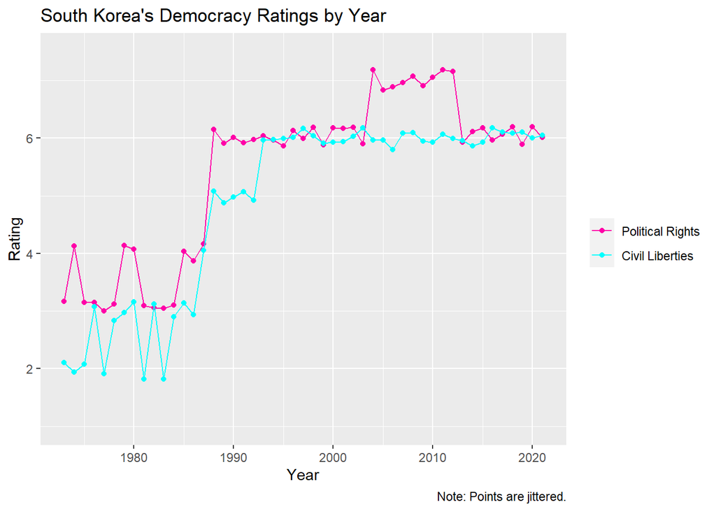

```r
country_data %>%
  drop_na(pr) %>%
  ggplot(aes(x = year)) +
  geom_point(aes(y = pr, color = "Political Rights"),
             position = position_jitter(width = 0, height = 0.2, seed = 72)) +
  geom_path(aes(y = pr, color = "Political Rights"),
            position = position_jitter(width = 0, height = 0.2, seed = 72)) +
  geom_point(aes(y = cl, color = "Civil Liberties"),
             position = position_jitter(width = 0, height = 0.2, seed = 60)) +
  geom_path(aes(y = cl, color = "Civil Liberties"),
            position = position_jitter(width = 0, height = 0.2, seed = 60)) +
  scale_y_continuous(limits = c(1, 7.5)) +
  scale_color_manual(breaks = c("Political Rights", "Civil Liberties"),
                        values=c("#FF00A8", "#00ffff")) +
  labs(
    title = glue("{given_country}'s Democracy Ratings by Year"),
    caption = "Note: Points are jittered.",
    x = "Year",
    y = "Rating",
    color = NULL
  )
```

We can also see how a given country compares to other countries in their continent on political rights.

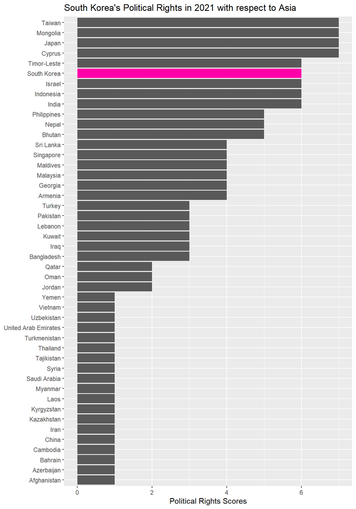

```r
fh_clean %>%
  filter(year == most_recent,
         continent == country_continent) %>%
  ggplot(aes(x = fct_reorder(country, pr), y = pr)) +
  geom_col() +
  geom_col(data = country_data %>% filter(year == most_recent), fill = "#FF00A8") +
  coord_flip() +
  labs(
    title = glue("{given_country}'s Political Rights in {most_recent} with respect to {country_continent}"),
    x = NULL,
    y = "Political Rights Scores"
  )
```